# Practicum II - Mine a Database, CS5200 Spring 2021

### Part 1 Load XML: Create a normalized relational OLTP database

```r
#pacman (package manager) installs and loads packages if not installed
pacman::p_load(pacman, RSQLite, XML, DBI, tidyverse)

#create db to set schema and load data to
dbs <- dbConnect(RSQLite::SQLite(), "pubMed0.db")
```

### Part 1 Populate relational database with data from an XML document

```r
path <- "/Users/jeannille/repos/mine_a_database/"
xmlFile <- "pubmed_sample.xml"
fpn <- paste0(path,xmlFile)

xml_data <- xmlParse(file = fpn)
nodes <- getNodeSet(xml_data, "//PubmedArticle")
r <- xmlRoot(xml_data)

# Get the name of the node to confirm
xmlName(r)
```

```
[1] "PubmedArticleSet"
```

```r
#PubmedArticleSet

#get number of children of root, number of pubMedArticles (19)
numPubMeds <- xmlSize(r)
```

```r
newJournal.df <- data.frame(ISSN = character(),#cant be numeric with a hyphen?
                          journalTitle = character(),
                          ISOabbrevation = character(),
                          volume = numeric(),
                          Issue = numeric(),
                          #pubYear = numeric(),
                          #pubMonth = character(),
                          stringsAsFactors = F)

colnames(newJournal.df) <- c("ISSN","journalTitle",
                             "ISOabbrevation","Issue","volume")#,"pubYear","pubMonth")

r <- xmlRoot(xml_data)

for (m in 1:19)
{

  aJournalNode <- r[[m]][[1]][['Article']][['Journal']] #

  aJournal <- aJournalNode[[m]]
  ISSN <- xpathSApply(aJournalNode, "./ISSN", xmlValue)
  journalTitle <- xpathSApply(aJournalNode, "./Title", xmlValue)
  ISOabbrevation <- xpathSApply(aJournalNode, "./ISOAbbreviation", xmlValue)
  volume<-xpathSApply(aJournalNode, "./JournalIssue/Volume", xmlValue)
  Issue <-xpathSApply(aJournalNode, "./JournalIssue/Issue", xmlValue)

  #pubYear<-xpathSApply(aJournalNode, "./JournalIssue/PubDate/Year", xmlValue)
  #pubMonth <-xpathSApply(aJournalNode, "./JournalIssue/PubDate/Month", xmlValue)


  if (length(ISSN) == 0)
    ISSN <- ""
  if (length(journalTitle) == 0)
    journalTitle <- ""
  if (length(ISOabbrevation) == 0)
    ISOabbrevation <- ""
  #if (length(pubMonth) == 0)
  #  pubMonth <- ""

  newJournal.df[m,1] <- ISSN
  newJournal.df[m,2] <- journalTitle
  newJournal.df[m,3] <- ISOabbrevation
  newJournal.df[m,4] <- volume
  newJournal.df[m,5] <- Issue
  #newJournal.df[m,6] <- pubYear
  #newJournal.df[m,7] <- pubMonth
}
```

```r
#commented out so not seen in a knitted file
newJournal.df
```

|  | ISSN | journalTitle | ISOabbrevation | Issue | volume |
| --- | --- | --- | --- | --- | --- |
| 1 | 1556-3316 | HSS journal : the musculoskeletal journal of Hospital for Special Surgery | HSS J | 8 | 2 |
| 2 | 1545-7206 | Psychosomatics | Psychosomatics | 54 | 2 |
| 3 | 1524-4628 | Stroke; a journal of cerebral circulation | Stroke | 43 | 11 |
| 4 | 1532-8651 | Regional anesthesia and pain medicine | Reg Anesth Pain Med | 37 | 6 |
| 5 | 1532-2688 | Seizure : the journal of the British Epilepsy Association | Seizure | 22 | 1 |
| 6 | 1528-1132 | Clinical orthopaedics and related research | Clin. Orthop. Relat. Res. | 471 | 1 |
| 7 | 1532-8406 | The Journal of arthroplasty | J Arthroplasty | 27 | 10 |
| 8 | 1528-1175 | Anesthesiology | Anesthesiology | 117 | 1 |
| 9 | 1432-1998 | Pediatric radiology | Pediatr Radiol | 42 | 8 |
| 10 | 1530-0358 | Diseases of the colon and rectum | Dis. Colon Rectum | 55 | 4 |

[output cut: 9 more lines]

```r
newArticle.df <- data.frame(PMID = numeric(), #
                          journalISSN = character(),
                          articleTitle = character(),
                          pagination = character(),
                          #elocationID can have more then 1. need another table for that?
                          #same with abstract
                          #and author list- different table? what to use as a key?
                          language = character(),
                          #grant list?
                          #publication type tist?
                          artYear = numeric(),
                          artMonth = numeric(),
                          artDay = numeric(),
                          pubYear = numeric(),
                          pubMonth = character(),
                          stringsAsFactors = F)

colnames(newArticle.df) <- c("PMID","journalISSN",
                             "articleTitle","pagination","language",
                             "artYear", "artMonth", "artDay", 'pubYear', "pubMonth")#

r <- xmlRoot(xml_data)

for (m in 1:19)
{

  anArticleNode <- r[[m]][[1]][['Article']]#[['Journal']] #

  PMID <- xpathSApply(r[[m]][[1]], "./PMID", xmlValue)
  journalISSN <- xpathSApply(anArticleNode, "./Journal/ISSN", xmlValue)
  articleTitle <- xpathSApply(anArticleNode, "./ArticleTitle", xmlValue)
  pagination <- xpathSApply(anArticleNode, "./Pagination/MedlinePgn", xmlValue)
  language <- xpathSApply(anArticleNode, "./Language", xmlValue)

  artYear <- xpathSApply(anArticleNode, "./ArticleDate/Year", xmlValue)
  artMonth <- xpathSApply(anArticleNode, "./ArticleDate/Month", xmlValue)
  artDay <- xpathSApply(anArticleNode, "./ArticleDate/Day", xmlValue)

  pubYear <- xpathSApply(anArticleNode, "./Journal/JournalIssue/PubDate/Year", xmlValue)
  pubMonth <- xpathSApply(anArticleNode, "./Journal/JournalIssue/PubDate/Month", xmlValue)


  if (length(PMID) == 0)
    PMID <- ""
  if (length(journalISSN) == 0)
    journalISSN <- ""
  if (length(articleTitle) == 0)
    articleTitle <- ""
  if (length(pagination) == 0)
    pagination <- ""
  if (length(language) == 0)
    language <- ""
  if (length(artYear) == 0)
    artYear <- ""
  if (length(artMonth) == 0)
    artMonth <- ""
  if (length(artDay) == 0)
    artDay <- ""

  if (length(pubYear) == 0)
    pubYear <- ""
  if (length(pubMonth) == 0)
    pubMonth <- ""

  newArticle.df[m,1] <- PMID
  newArticle.df[m,2] <- journalISSN
  newArticle.df[m,3] <- articleTitle
  newArticle.df[m,4] <- pagination
  newArticle.df[m,5] <- language
  newArticle.df[m,6] <- artYear
  newArticle.df[m,7] <- artMonth
  newArticle.df[m,8] <- artDay
  newArticle.df[m,9] <- pubYear
  newArticle.df[m,10] <- pubMonth
}
```

|  | PMID | journalISSN | articleTitle | pagination | language | artYear | artMonth | artDay | pubYear | pubMonth |
| --- | --- | --- | --- | --- | --- | --- | --- | --- | --- | --- |
| 1 | 23874253 | 1556-3316 | Regional anesthesia for children undergoing orthopedic ambulatory surgeries in the United States, 1996-2006. | 133-6 | eng | 2012 | 06 | 20 | 2012 | Jul |
| 2 | 23194934 | 1545-7206 | Demographics and perioperative outcome in patients with depression and anxiety undergoing total joint arthroplasty: a population-based study. | 149-57 | eng | 2012 | 11 | 27 |  |  |
| 3 | 23091119 | 1524-4628 | Cerebrovascular reserve and stroke risk in patients with carotid stenosis or occlusion: a systematic review and meta-analysis. | 2884-91 | eng |  |  |  | 2012 | Nov |
| 4 | 23080348 | 1532-8651 | Comparative perioperative outcomes associated with neuraxial versus general anesthesia for simultaneous bilateral total knee arthroplasty. | 638-44 | eng |  |  |  |  |  |
| 5 | 23068970 | 1532-2688 | Vagus nerve stimulation vs. corpus callosotomy in the treatment of Lennox-Gastaut syndrome: a meta-analysis. | 3-8 | eng | 2012 | 10 | 12 | 2013 | Jan |
| 6 | 23008025 | 1528-1132 | Have bilateral total knee arthroplasties become safer? A population-based trend analysis. | 17-25 | eng | 2012 | 09 | 25 | 2013 | Jan |
| 7 | 22677144 | 1532-8406 | The metabolic syndrome in patients undergoing knee and hip arthroplasty: trends and in-hospital outcomes in the United States. | 1743-1749.e1 | eng | 2012 | 06 | 05 | 2012 | Dec |
| 8 | 22634871 | 1528-1175 | Utilization of critical care services among patients undergoing total hip and knee arthroplasty: epidemiology and risk factors. | 107-16 | eng |  |  |  | 2012 | Jul |
| 9 | 22434554 | 1432-1998 | Visualization of the normal appendix with MR enterography in children. | 959-64 | eng | 2012 | 03 | 21 | 2012 | Aug |
| 10 | 22426260 | 1530-0358 | FDG-PET assessment of rectal cancer response to neoadjuvant chemoradiotherapy is not associated with long-term prognosis: a prospective evaluation. | 378-86 | eng |  |  |  | 2012 | Apr |

[output cut: 9 more lines]

```r
newAuthor.df <- data.frame(PMID = numeric(),
                          lastName = character(),
                          foreName = character(),
                          initials = character(),
                          affiliation = character(),
                          stringsAsFactors = F)

colnames(newAuthor.df) <- c("PMID","lastName","foreName",
                             "initials","affiliation")

r <- xmlRoot(xml_data)
rowCount <- 1
for (m in 1:19)
{

  PMID <- xpathSApply(r[[m]][[1]], "./PMID", xmlValue)
  if (length(PMID) == 0)
    PMID <- ""

  anAuthorNodeList <- r[[m]][[1]][['Article']][['AuthorList']]

  j<-xmlSize(anAuthorNodeList)


  for (k in 1:j){

    node <-anAuthorNodeList[[k]]
    lastName <- xpathSApply(node, "./LastName", xmlValue)
    foreName <- xpathSApply(node, "./ForeName", xmlValue)
    initials <- xpathSApply(node, "./Initials", xmlValue)
    affiliation <- xpathSApply(node, "./Affiliation", xmlValue)

    if (length(lastName) == 0)
      lastName <- ""
    if (length(foreName) == 0)
      foreName <- ""
    if (length(initials) == 0)
      initials <- ""
    if (length(affiliation) == 0)
      affiliation <- ""

    newAuthor.df[rowCount,1] <- PMID
    newAuthor.df[rowCount,2] <- lastName
    newAuthor.df[rowCount,3] <- foreName
    newAuthor.df[rowCount,4] <- initials
    newAuthor.df[rowCount,5] <- affiliation


    rowCount <- rowCount+1
  }

}
```

```r
#commented out so not seen in a knitted file
#newAuthor.df
```

```r
newHistory.df <- data.frame(PMID = numeric(),
                          pubStatus = character(),
                          year = numeric(),
                          month = numeric(),
                          day = numeric(),
                          #hour and minute not useful for analysis?
                          stringsAsFactors = F)

colnames(newHistory.df) <- c("PMID","pubStatus","year",
                             "month","day")

r <- xmlRoot(xml_data)
rowCount <- 1
for (m in 1:19)
{

  PMID <- xpathSApply(r[[m]][[1]], "./PMID", xmlValue)
  if (length(PMID) == 0)
    PMID <- ""

  aHistoryList <- r[[m]][['PubmedData']][['History']]

  j<-xmlSize(aHistoryList)


  for (k in 1:j){

    node <-aHistoryList[[k]]

    pubStatus <- xmlGetAttr(node,'PubStatus')

    year <- xpathSApply(node, "./Year", xmlValue)
    month <- xpathSApply(node, "./Month", xmlValue)
    day <- xpathSApply(node, "./Day", xmlValue)


    if (length(pubStatus) == 0)
      pubStatus <- ""
    if (length(year) == 0)
      year <- ""
    if (length(month) == 0)
      month <- ""
    if (length(day) == 0)
      day <- ""

    newHistory.df[rowCount,1] <- PMID
    newHistory.df[rowCount,2] <- pubStatus
    newHistory.df[rowCount,3] <- year
    newHistory.df[rowCount,4] <- month
    newHistory.df[rowCount,5] <- day


    rowCount <- rowCount+1
  }

}
```

```r
#commented out so not seen in a knitted file
newHistory.df
```

|  | PMID | pubStatus | year | month | day |
| --- | --- | --- | --- | --- | --- |
| 1 | 23874253 | received | 2012 | 1 | 15 |
| 2 | 23874253 | accepted | 2012 | 4 | 16 |
| 3 | 23874253 | epublish | 2012 | 6 | 20 |
| 4 | 23874253 | entrez | 2013 | 7 | 23 |
| 5 | 23874253 | pubmed | 2013 | 7 | 23 |
| 6 | 23874253 | medline | 2013 | 7 | 23 |
| 7 | 23194934 | received | 2012 | 7 | 16 |
| 8 | 23194934 | revised | 2012 | 8 | 17 |
| 9 | 23194934 | accepted | 2012 | 8 | 20 |
| 10 | 23194934 | aheadofprint | 2012 | 11 | 27 |

[output cut: 84 more lines]

Clear tables as needed

```sql
DROP TABLE IF EXISTS Journal
```

```sql
DROP TABLE IF EXISTS Article
```

```sql
DROP TABLE IF EXISTS Authorship
```

```sql
DROP TABLE IF EXISTS Author
```

```sql
DROP TABLE IF EXISTS History
```

Create tables from ERD

```sql
CREATE TABLE IF NOT EXISTS Journal (
  ISSN varchar(255) PRIMARY KEY,
  title varchar(255),
  ISOabbrevation varchar(255),
  volume varchar(255),
  issue varchar(255)

  );
```

```sql
CREATE TABLE IF NOT EXISTS Article (
  PMID int(255) NOT NULL,
  journalISSN varchar(255),
  title varchar(255),
  pagination varchar(255),
  language varchar(255),
  FOREIGN KEY (journalISSN ) REFERENCES Journal(ISSN)
  );
```

histKey INTEGER primary key AUTOINCREMENT,

use compound key instead?

```sql
CREATE TABLE IF NOT EXISTS History (
  PMID int(255),
  pubStatus varchar(255),
  year int(255),
  month int(255),
  day int(255),
  PRIMARY  KEY (PMID, pubStatus),
  FOREIGN KEY (PMID) REFERENCES Article(PMID)
  );
```

adding in this lookup table might need compound primary key?

```sql
CREATE TABLE IF NOT EXISTS Authorship (
  lookupKey INTEGER primary key AUTOINCREMENT,
  PMID int(255),
  lastName varchar(255),
  foreName varchar(255),
  FOREIGN KEY (PMID) REFERENCES Article(PMID),
  FOREIGN KEY (lastName, foreName) REFERENCES Author(lastName, foreName)
  );
```

PMID int(255),

, FOREIGN KEY (PMID) REFERENCES Article(PMID)

```sql
CREATE TABLE IF NOT EXISTS Author (
  authorKey INTEGER primary key AUTOINCREMENT,
  lastName varchar(255),
  foreName varchar(255),
  initials varchar(255),
  affiliation varchar(255)
  );
```

Check all tables have been correctly added to database

```r
dbListTables(dbs)
```

```
[1] "Article"         "Author"          "Authorship"      "History"         "Journal"
[6] "authorData"      "histData"        "sqlite_sequence"
```

16 distinct journals, but dbs will remain with the 3 dups for purposes of querying

```sql
SELECT ISSN,journalTitle,ISOabbrevation, volume, issue from journalData
GROUP BY ISSN
```

Part 1 Journal table

Inserting data (dataframe) into tables that have been created in pubMedData database

[output not shown]

[output cut: 6 more lines]

Drop temporary table for Journal

```sql
DROP TABLE journalData
```

write article df to database

```r
dbWriteTable(dbs, "articleData",newArticle.df )
```

```sql
SELECT distinct PMID from articleData
```

| PMID |
| --- |
| 23874253 |
| 23194934 |
| 23091119 |
| 23080348 |
| 23068970 |
| 23008025 |
| 22677144 |
| 22634871 |
| 22434554 |
| 22426260 |

[output cut: 9 more lines]

Remove year/ month/day? , year,month,day , artYear,artMonth,artDay

```sql
INSERT INTO Article (PMID , journalISSN, title, pagination,language)
SELECT  PMID, journalISSN, articleTitle, pagination,language
FROM articleData
```

```sql
SELECT * from Article LIMIT 10
```

| PMID | journalISSN | title | pagination | language |
| --- | --- | --- | --- | --- |
| 23874253 | 1556-3316 | Regional anesthesia for children undergoing orthopedic ambulatory surgeries in the United States, 1996-2006. | 133-6 | eng |
| 23194934 | 1545-7206 | Demographics and perioperative outcome in patients with depression and anxiety undergoing total joint arthroplasty: a population-based study. | 149-57 | eng |
| 23091119 | 1524-4628 | Cerebrovascular reserve and stroke risk in patients with carotid stenosis or occlusion: a systematic review and meta-analysis. | 2884-91 | eng |
| 23080348 | 1532-8651 | Comparative perioperative outcomes associated with neuraxial versus general anesthesia for simultaneous bilateral total knee arthroplasty. | 638-44 | eng |
| 23068970 | 1532-2688 | Vagus nerve stimulation vs. corpus callosotomy in the treatment of Lennox-Gastaut syndrome: a meta-analysis. | 3-8 | eng |
| 23008025 | 1528-1132 | Have bilateral total knee arthroplasties become safer? A population-based trend analysis. | 17-25 | eng |
| 22677144 | 1532-8406 | The metabolic syndrome in patients undergoing knee and hip arthroplasty: trends and in-hospital outcomes in the United States. | 1743-1749.e1 | eng |
| 22634871 | 1528-1175 | Utilization of critical care services among patients undergoing total hip and knee arthroplasty: epidemiology and risk factors. | 107-16 | eng |
| 22434554 | 1432-1998 | Visualization of the normal appendix with MR enterography in children. | 959-64 | eng |
| 22426260 | 1530-0358 | FDG-PET assessment of rectal cancer response to neoadjuvant chemoradiotherapy is not associated with long-term prognosis: a prospective evaluation. | 378-86 | eng |

```sql
DROP TABLE articleData
```

```r
dbWriteTable(dbs, "histData",newHistory.df , overwrite = TRUE)
```

History information for the 19 published articles, use year-month-date form this table for star schema

```sql
SELECT  DiSTINCT * FROM histData  WHERE pubStatus = "pubmed"
```

| PMID | pubStatus | year | month | day |
| --- | --- | --- | --- | --- |
| 23874253 | pubmed | 2013 | 7 | 23 |
| 23194934 | pubmed | 2012 | 12 | 1 |
| 23091119 | pubmed | 2012 | 10 | 24 |
| 23080348 | pubmed | 2012 | 10 | 20 |
| 23068970 | pubmed | 2012 | 10 | 17 |
| 23008025 | pubmed | 2012 | 9 | 26 |
| 22677144 | pubmed | 2012 | 6 | 9 |
| 22634871 | pubmed | 2012 | 5 | 29 |
| 22434554 | pubmed | 2012 | 3 | 22 |
| 22426260 | pubmed | 2012 | 3 | 20 |

[output cut: 9 more lines]

```sql
INSERT INTO History (PMID , pubStatus, year, month,day)
SELECT  PMID , pubStatus, year, month,day
FROM histData
```

```sql
SELECT * from History LIMIT 10
```

| PMID | pubStatus | year | month | day |
| --- | --- | --- | --- | --- |
| 23874253 | received | 2012 | 1 | 15 |
| 23874253 | accepted | 2012 | 4 | 16 |
| 23874253 | epublish | 2012 | 6 | 20 |
| 23874253 | entrez | 2013 | 7 | 23 |
| 23874253 | pubmed | 2013 | 7 | 23 |
| 23874253 | medline | 2013 | 7 | 23 |
| 23194934 | received | 2012 | 7 | 16 |
| 23194934 | revised | 2012 | 8 | 17 |
| 23194934 | accepted | 2012 | 8 | 20 |
| 23194934 | aheadofprint | 2012 | 11 | 27 |

```r
dbWriteTable(dbs, "authorData",newAuthor.df, overwrite = TRUE)
```

```sql
SELECT * from authorData LIMIT 10
```

| PMID | lastName | foreName | initials | affiliation |
| --- | --- | --- | --- | --- |
| 23874253 | Kuo | Cassie | C | Department of Anesthesiology, Hospital for Special Surgery, 535 East 70th Street, New York, NY 10021 USA. |
| 23874253 | Edwards | Alison | A |  |
| 23874253 | Mazumdar | Madhu | M |  |
| 23874253 | Memtsoudis | Stavros G | SG |  |
| 23194934 | Stundner | Ottokar | O | Department of Anesthesiology, Hospital for Special Surgery, Weill Medical College of Cornell University, New York, NY, USA. |
| 23194934 | Kirksey | Meghan | M |  |
| 23194934 | Chiu | Ya Lin | YL |  |
| 23194934 | Mazumdar | Madhu | M |  |
| 23194934 | Poultsides | Lazaros | L |  |
| 23194934 | Gerner | Peter | P |  |

```sql
INSERT INTO Author ( lastName, foreName, initials,affiliation)
SELECT   lastName, foreName, initials,affiliation
FROM authorData
```

```sql
SELECT distinct * from Author limit 10
```

| authorKey | lastName | foreName | initials | affiliation |
| --- | --- | --- | --- | --- |
| 1 | Kuo | Cassie | C | Department of Anesthesiology, Hospital for Special Surgery, 535 East 70th Street, New York, NY 10021 USA. |
| 2 | Edwards | Alison | A |  |
| 3 | Mazumdar | Madhu | M |  |
| 4 | Memtsoudis | Stavros G | SG |  |
| 5 | Stundner | Ottokar | O | Department of Anesthesiology, Hospital for Special Surgery, Weill Medical College of Cornell University, New York, NY, USA. |
| 6 | Kirksey | Meghan | M |  |
| 7 | Chiu | Ya Lin | YL |  |
| 8 | Mazumdar | Madhu | M |  |
| 9 | Poultsides | Lazaros | L |  |
| 10 | Gerner | Peter | P |  |

Initials is not included in the keys for Authorship because it dosent impact the results. 84 unique first and last name pairs, and 84 first, last and initial pairs.

```sql
INSERT INTO Authorship ( PMID, lastName, foreName)
SELECT   PMID, lastName, foreName
FROM authorData
```

Total Authorship (can include author multiple times as they can contirbute to multiple instances of articles, 272 rows)

```sql
SELECT DISTINCT * from Authorship LIMIT 10
```

| lookupKey | PMID | lastName | foreName |
| --- | --- | --- | --- |
| 1 | 23874253 | Kuo | Cassie |
| 2 | 23874253 | Edwards | Alison |
| 3 | 23874253 | Mazumdar | Madhu |
| 4 | 23874253 | Memtsoudis | Stavros G |
| 5 | 23194934 | Stundner | Ottokar |
| 6 | 23194934 | Kirksey | Meghan |
| 7 | 23194934 | Chiu | Ya Lin |
| 8 | 23194934 | Mazumdar | Madhu |
| 9 | 23194934 | Poultsides | Lazaros |
| 10 | 23194934 | Gerner | Peter |

Drop tempororay authorData table

```sql
DROP TABLE authorData
```

### Part 2 Star schema, establish connection to star schema db

```r
star.dbs <- dbConnect(RSQLite::SQLite(), "pubMedStar0.db")
```

```sql
--use to clear tables at start
DROP TABLE IF EXISTS dimAuthor;
```

```sql
DROP TABLE IF EXISTS dimPubDate;
```

```sql
DROP TABLE IF EXISTS dimJournal;
```

```sql
DROP TABLE IF EXISTS dimHistory;
```

```sql
DROP TABLE IF EXISTS factArticle;
```

tracks number of articles per quarter, month, year

```sql
DROP TABLE IF EXISTS numArticleSummary;
```

## realize star schema tables

```sql
CREATE TABLE IF NOT EXISTS dimAuthor(
  authorRef INTEGER,
 -- PMID INTEGER NOT NULL,
  lastName TEXT,
  foreName TEXT,
  initials TEXT,
  affiliation TEXT,
  PRIMARY KEY(authorRef)
  );
```

#pubMedDate col

```sql
CREATE TABLE IF NOT EXISTS dimPubDate(
  dateRef INTEGER PRIMARY KEY AUTOINCREMENT,
  PMID INTEGER,
  datePublished TEXT,
  month INTEGER,
  day INTEGER,
  year INTEGER,
  quarter INTEGER
  );
```

update this to associate with every article (even if multiple articles published to same journal, dimension table should focus on articles in a particular context, center table?, or could just grab from article itself)

```sql
CREATE TABLE IF NOT EXISTS dimJournal(
  journalRef INTEGER PRIMARY KEY AUTOINCREMENT,
  ISSN TEXT,
  title TEXT,
  ISOabbrevation TEXT
  --volume TEXT NULL,
  --issue TEXT NULL,
  );
```

```sql
CREATE TABLE IF NOT EXISTS dimHistory(
  historyRef INTEGER PRIMARY KEY AUTOINCREMENT,
  articleId INTEGER,
  articleTitle TEXT,
  pubStatus INTEGER
  );
```

factArticle compound key - (pmid, authorRef) connect author to specific article

```sql
CREATE TABLE IF NOT EXISTS factArticle(
  PMID INTEGER,
  articleTitle TEXT,
  authorRef INTEGER,
  journalRef INTEGER,
  dateRef INTEGER,
  historyRef INTEGER,
  FOREIGN KEY (authorRef) REFERENCES dimAuthor(authorRef),
  FOREIGN KEY (journalRef) REFERENCES dimJournal(journalRef),
  FOREIGN KEY (dateRef) REFERENCES dimPubDate(dateRef),
  FOREIGN KEY (historyRef) REFERENCES dimHistory(historyRef),
  PRIMARY KEY (PMID)
);
```

```sql
CREATE TABLE IF NOT EXISTS numArticleSummary(
  summaryId INTEGER PRIMARY KEY AUTOINCREMENT,
  numOfArticles INTEGER NOT NULL,
  quarter INTEGER,
  year INTEGER,
  month INTEGER
);
```

```r
dbListTables(star.dbs)
```

```
[1] "dimAuthor"               "dimHistory"              "dimJournal"
[4] "dimPubDate"              "factArticle"             "numArticleSummary"
[7] "pubDate"                 "sqlite_sequence"         "summaryArticlesQuantity"
```

Purpose of star schema is to have eaisly accessible look up tables (LinkedIn learning) - Context tables Part 2. Populate Star Schema tables using populated OLTP database. First, update the dimension tables. Then we can use look up keys for these to populate

Create temp (star schema) data frames from dbs database using queries to populate Star Schema tables

| authorRef | foreName | lastName | initials | affiliation |
| --- | --- | --- | --- | --- |
| 1 | Cassie | Kuo | C | Department of Anesthesiology, Hospital for Special Surgery, 535 East 70th Street, New York, NY 10021 USA. |
| 2 | Alison | Edwards | A |  |
| 3 | Madhu | Mazumdar | M |  |
| 4 | Stavros G | Memtsoudis | SG |  |
| 5 | Ottokar | Stundner | O | Department of Anesthesiology, Hospital for Special Surgery, Weill Medical College of Cornell University, New York, NY, USA. |
| 6 | Meghan | Kirksey | M |  |
| 7 | Ya Lin | Chiu | YL |  |
| 8 | Madhu | Mazumdar | M |  |
| 9 | Lazaros | Poultsides | L |  |
| 10 | Peter | Gerner | P |  |

[output cut: 262 more lines]

Populate Star schema tables

```r
#star.dbs <- dbConnect(RSQLite::SQLite(), "pubMedStar0.db")

dbWriteTable( star.dbs, "dimAuthor", df_AuthorStar, field.types = NULL, row.names = FALSE,
              overwrite = FALSE, append = TRUE, allow.keywords = FALSE )

dbReadTable( star.dbs, "dimAuthor")
```

| authorRef | lastName | foreName | initials | affiliation |
| --- | --- | --- | --- | --- |
| 1 | Kuo | Cassie | C | Department of Anesthesiology, Hospital for Special Surgery, 535 East 70th Street, New York, NY 10021 USA. |
| 2 | Edwards | Alison | A |  |
| 3 | Mazumdar | Madhu | M |  |
| 4 | Memtsoudis | Stavros G | SG |  |
| 5 | Stundner | Ottokar | O | Department of Anesthesiology, Hospital for Special Surgery, Weill Medical College of Cornell University, New York, NY, USA. |
| 6 | Kirksey | Meghan | M |  |
| 7 | Chiu | Ya Lin | YL |  |
| 8 | Mazumdar | Madhu | M |  |
| 9 | Poultsides | Lazaros | L |  |
| 10 | Gerner | Peter | P |  |

[output cut: 262 more lines]

```r
#dbListTables(star.dbs)
```

[output not shown]

[output cut: 9 more lines]

```sql
SELECT * FROM dimJournal LIMIT 10;
```

| journalRef | ISSN | title | ISOabbrevation |
| --- | --- | --- | --- |
| 1 | 1556-3316 | HSS journal : the musculoskeletal journal of Hospital for Special Surgery | HSS J |
| 2 | 1545-7206 | Psychosomatics | Psychosomatics |
| 3 | 1524-4628 | Stroke; a journal of cerebral circulation | Stroke |
| 4 | 1532-8651 | Regional anesthesia and pain medicine | Reg Anesth Pain Med |
| 5 | 1532-2688 | Seizure : the journal of the British Epilepsy Association | Seizure |
| 6 | 1528-1132 | Clinical orthopaedics and related research | Clin. Orthop. Relat. Res. |
| 7 | 1532-8406 | The Journal of arthroplasty | J Arthroplasty |
| 8 | 1528-1175 | Anesthesiology | Anesthesiology |
| 9 | 1432-1998 | Pediatric radiology | Pediatr Radiol |
| 10 | 1530-0358 | Diseases of the colon and rectum | Dis. Colon Rectum |

Populate article fact table now that dimension/context tables have been populated

[output not shown]

[output cut: 262 more lines]

queries db and result outputs into dataframe with pubstates, date and quarter output will be used to write to dimPubDate and dimHistory in star schema db

```sql
SELECT History.PMID AS PMID,
  History.pubStatus AS pubStatus,
  History.day || "-" || History.month || "-" || History.year AS datePublished,
  CASE
    WHEN History.month BETWEEN 1 AND 3 THEN 1
    WHEN History.month BETWEEN 4 AND 6 THEN 2
    WHEN History.month BETWEEN 7 AND 9 THEN 3
    WHEN History.month Between 10 AND 12 THEN 4
  END AS quarter
  FROM History
```

Query database to populate dimPubDate table (date dimension table) ## Output dimensoon table: dimHistory articleId, articleTitle, pubStatus

| historyRef | articleId | articleTitle | pubStatus |
| --- | --- | --- | --- |
| 1 | 23874253 | Regional anesthesia for children undergoing orthopedic ambulatory surgeries in the United States, 1996-2006. | accepted |
| 2 | 23874253 | Regional anesthesia for children undergoing orthopedic ambulatory surgeries in the United States, 1996-2006. | entrez |
| 3 | 23874253 | Regional anesthesia for children undergoing orthopedic ambulatory surgeries in the United States, 1996-2006. | epublish |
| 4 | 23874253 | Regional anesthesia for children undergoing orthopedic ambulatory surgeries in the United States, 1996-2006. | medline |
| 5 | 23874253 | Regional anesthesia for children undergoing orthopedic ambulatory surgeries in the United States, 1996-2006. | pubmed |
| 6 | 23874253 | Regional anesthesia for children undergoing orthopedic ambulatory surgeries in the United States, 1996-2006. | received |
| 7 | 23194934 | Demographics and perioperative outcome in patients with depression and anxiety undergoing total joint arthroplasty: a population-based study. | accepted |
| 8 | 23194934 | Demographics and perioperative outcome in patients with depression and anxiety undergoing total joint arthroplasty: a population-based study. | aheadofprint |
| 9 | 23194934 | Demographics and perioperative outcome in patients with depression and anxiety undergoing total joint arthroplasty: a population-based study. | entrez |
| 10 | 23194934 | Demographics and perioperative outcome in patients with depression and anxiety undergoing total joint arthroplasty: a population-based study. | medline |

[output cut: 84 more lines]

## Dimensoon table: dimPubDate

| dateRef | PMID | datePublished | month | day | year | quarter |
| --- | --- | --- | --- | --- | --- | --- |
| 1 | 23874253 | 15-1-2012 | 1 | 15 | 2012 | 1 |
| 2 | 23874253 | 16-4-2012 | 4 | 16 | 2012 | 2 |
| 3 | 23874253 | 20-6-2012 | 6 | 20 | 2012 | 2 |
| 4 | 23874253 | 23-7-2013 | 7 | 23 | 2013 | 3 |
| 5 | 23874253 | 23-7-2013 | 7 | 23 | 2013 | 3 |
| 6 | 23874253 | 23-7-2013 | 7 | 23 | 2013 | 3 |
| 7 | 23194934 | 16-7-2012 | 7 | 16 | 2012 | 3 |
| 8 | 23194934 | 17-8-2012 | 8 | 17 | 2012 | 3 |
| 9 | 23194934 | 20-8-2012 | 8 | 20 | 2012 | 3 |
| 10 | 23194934 | 27-11-2012 | 11 | 27 | 2012 | 4 |

[output cut: 84 more lines]

Join dim tables to create and populate center fact table of star schema

```sql
INSERT INTO factArticle(authorRef, journalRef, dateRef, historyRef, PMID)
SELECT dimPubDate.dateRef, dimAuthor.authorRef, dimJournal.journalRef, dimHistory.historyRef
FROM dimPubDate
JOIN dimAuthor ON factArticle.authorRef = dimAuthor.authorRef
JOIN dimJournal ON factArticle.journalRef = dimJournal.journalRef
JOIN dimHistory ON factArticle.historyRef = dimHistory.historyRef
JOIN dimPubDate ON factArticle.dateRef = dimPubDate.dateRef
```

Populate Article Fact table for all 19 articles (will contain all facts queried from all its connected dimension tables)

| PMID | articleTitle | authorRef | journalRef | dateRef | historyRef |
| --- | --- | --- | --- | --- | --- |
| 21301391 | Comparative safety of simultaneous and staged anterior and posterior spinal surgery. | 131 | 1 | 92 | 92 |
| 21778465 | Mortality of patients with respiratory insufficiency and adult respiratory distress syndrome after surgery: the obesity paradox. | 125 | 2 | 88 | 88 |
| 21851550 | Decision curve analysis assessing the clinical benefit of NMP22 in the detection of bladder cancer: secondary analysis of a prospective trial. | 114 | 3 | 84 | 84 |
| 22020835 | Impact of race on survival in patients with clinically nonmetastatic prostate cancer who deferred primary treatment. | 104 | 4 | 77 | 77 |
| 22024892 | Metabolic syndrome and lumbar spine fusion surgery: epidemiology and perioperative outcomes. | 97 | 5 | 74 | 74 |
| 22115762 | In-hospital patient falls after total joint arthroplasty: incidence, demographics, and risk factors in the United States. | 91 | 6 | 68 | 68 |
| 22189576 | Beyond repeated-measures analysis of variance: advanced statistical methods for the analysis of longitudinal data in anesthesia research. | 88 | 7 | 65 | 65 |
| 22235286 | Intra- and inter-tumor heterogeneity of BRAF(V600E))mutations in primary and metastatic melanoma. | 76 | 8 | 59 | 59 |
| 22305625 | Factors influencing unexpected disposition after orthopedic ambulatory surgery. | 70 | 9 | 52 | 52 |
| 22426260 | FDG-PET assessment of rectal cancer response to neoadjuvant chemoradiotherapy is not associated with long-term prognosis: a prospective evaluation. | 61 | 10 | 49 | 49 |

[output cut: 9 more lines]

```sql
--SELECT * FROM dimPubDate

SELECT COUNT(factArticle.PMID) as numOfArticles, dimPubDate.quarter, year FROM factArticle
JOIN dimPubDate ON dimPubDate.dateRef = factArticle.dateRef
GROUP BY dimPubDate.quarter, dimPubDate.year;
--JOIN dimAuthor ON factArticle.authorRef = dimAuthor.authorRef
--JOIN dimJournal ON factArticle.journalRef = dimJournal.journalRef
--JOIN dimHistory ON factArticle.historyRef = dimHistory.historyRef
```

Query for number of articles per quarter by joining dimension tables on Article fact table

```sql
SELECT COUNT(factArticle.PMID) as numberOfArticles, dimPubDate.quarter
FROM factArticle
JOIN dimPubDate ON dimPubDate.dateRef = factArticle.dateRef
JOIN dimAuthor ON factArticle.authorRef = dimAuthor.authorRef
JOIN dimJournal ON factArticle.journalRef = dimJournal.journalRef
GROUP BY dimPubDate.quarter;
```

```sql
SELECT dimAuthor.lastName, dimAuthor.foreName, dimPubDate.quarter FROM factArticle
JOIN dimAuthor ON factArticle.authorRef = dimAuthor.authorRef
JOIN dimPubDate ON factArticle.dateRef = dimPubDate.dateRef
```

| lastName | foreName | quarter |
| --- | --- | --- |
| Passias | Peter G | 1 |
| Memtsoudis | Stavros G | 3 |
| Barbieri | Christopher E | 3 |
| Koscuiszka | Michael | 2 |
| Memtsoudis | Stavros G | 4 |
| Memtsoudis | Stavros G | 1 |
| Ma | Yan | 4 |
| Yancovitz | Molly | 3 |
| Memtsoudis | Stavros G | 2 |
| Ruby | Jeannine A | 1 |

[output cut: 9 more lines]

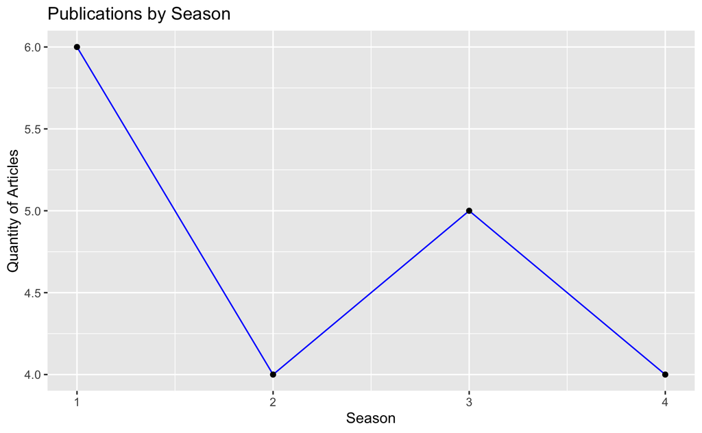

```r
viz <- ggplot(data = articlesBySeason, aes(x = quarter, y = numberOfArticles, group = 1 )) + geom_line( color = 'blue') + geom_point() + labs(title="Publications by Season", x="Season", y="Quantity of Articles")

viz
```

```r
# viz <- ggplot(data = newData, aes(x = strikeYear, y = numOfStrikes, group = 1)) +
#   geom_point(aes(color=numOfStrikes), alpha=0.9) + geom_line() +
#   labs(title= "Birds Strikes Incidents by Year ", subtitle="Years 2000 - 2011", x= "Year", y="Number of Bird Strikes")


#articlesBySeason
```

```r
dbGetQuery(star.dbs, "SELECT * FROM dimHistory GROUP BY pubStatus")
```

| historyRef | articleId | articleTitle | pubStatus |
| --- | --- | --- | --- |
| 1 | 23874253 | Regional anesthesia for children undergoing orthopedic ambulatory surgeries in the United States, 1996-2006. | accepted |
| 8 | 23194934 | Demographics and perioperative outcome in patients with depression and anxiety undergoing total joint arthroplasty: a population-based study. | aheadofprint |
| 2 | 23874253 | Regional anesthesia for children undergoing orthopedic ambulatory surgeries in the United States, 1996-2006. | entrez |
| 3 | 23874253 | Regional anesthesia for children undergoing orthopedic ambulatory surgeries in the United States, 1996-2006. | epublish |
| 4 | 23874253 | Regional anesthesia for children undergoing orthopedic ambulatory surgeries in the United States, 1996-2006. | medline |
| 5 | 23874253 | Regional anesthesia for children undergoing orthopedic ambulatory surgeries in the United States, 1996-2006. | pubmed |
| 6 | 23874253 | Regional anesthesia for children undergoing orthopedic ambulatory surgeries in the United States, 1996-2006. | received |
| 13 | 23194934 | Demographics and perioperative outcome in patients with depression and anxiety undergoing total joint arthroplasty: a population-based study. | revised |

Query that sorts by quarter - get from star schema

```r
# (SELECT PMID, quarter FROM (SELECT * FROM dimHistory GROUP BY PMID)
#numArticleSummary numOfArticles, auarter, year, month (summaryId auto)

#subquery that groups by articles, resulting in 19 unique articles and their history
to = " SELECT pmid, quarter FROM dimHistory
GROUP BY PMID "

sqlCmd = " SELECT quarter, COUNT(*) AS 'numOfarticles' FROM (SELECT pmid, quarter FROM dimPubDate
GROUP BY PMID) GROUP BY quarter"
#get mpid and quarter of each unique article


byQuarter <- dbGetQuery(star.dbs, sqlCmd)
byQuarter

dbGetQuery(star.dbs, "SELECT * FROM dimPubDate")

dbGetQuery(star.dbs, "SELECT * FROM factArticle JOIN dimPubDate ON dimPubDate.")

# numOfArticles INTEGER NOT NULL,
# quarter INTEGER,
# year INTEGER,
# month INTEGER
```

[output not shown]

```r
dbListTables(star.dbs)
```

```
[1] "dimAuthor"               "dimHistory"              "dimJournal"
[4] "dimPubDate"              "factArticle"             "numArticleSummary"
[7] "pubDate"                 "sqlite_sequence"         "summaryArticlesQuantity"
```

### Part 3 use the OLAP star/snowflake schema to do some (simple) data mining